# Cahier des charges du minisite

## # Cahier des Charges : Site Web sur un Acteur de l’Architecture de l’Information

### Introduction

Ce cahier des charges détaille la conception d’un site web dédié à un acteur ou actrice majeure de l’architecture de l’information, du design de l’information ou un théoricien des sciences de l’information. Le site se doit d’être informatif, visuellement cohérent et facilement navigable. Pensez aussi que cette réalisation peut figurer à votre *portfolio* et que ce n’est pas seulement un simple exercice. Cela peut-être l’occasion de développer votre propre *vision* informationnelle. La réalisation est donc strictement *personnelle*.

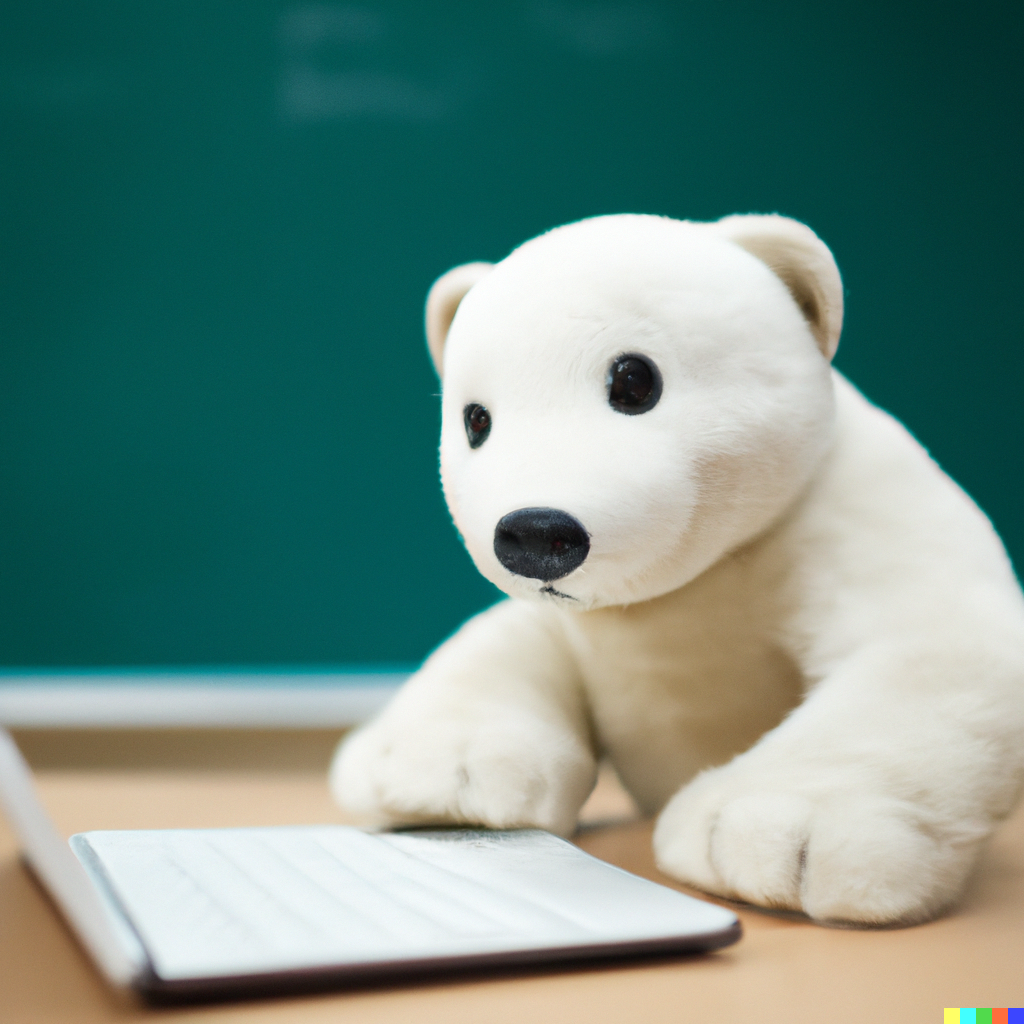

## Objectifs

- Présenter de manière claire et concise l’acteur choisi et sa contribution au domaine.
- Assurer une cohérence visuelle en rapport avec l’acteur ou ses travaux.
- Fournir une arborescence claire pour faciliter la navigation.
- Cibler les professionnels et étudiants dans le domaine de l’architecture et du design de l’information. D’autres cibles complémentaires sont possibles, voire une autre hiérarchie dans la cible (par exemple d’abord des chercheurs, ensuite des praticiens, etc.) Il faudra simplement justifier vos décisions.

### Arborescence

L’aborescence présentée ci-dessous est un modèle qu’il est possible de changer et de faire évoluer en fonction des besoins. Il vous faudra justifier et expliquer vos choix. Il s’agit aussi de montrer une *progression* par rapport à ce que vous avez pu réaliser en 1A et 2A.

1. **Accueil**
   - Brève introduction de l’acteur.
   - Image ou illustration pertinente.
   - Liens vers les principales sections du site.
2. **Biographie**
   - Historique de l’acteur, formation et carrière.
   - Contributions majeures au domaine.
3. **Travaux & Publications**
   - Liste des travaux, articles, livres, etc.
   - Liens vers deses textes complets (si disponibles), des interventions vidéos, etc..
4. **Galerie**
   - Images, illustrations ou schémas représentatifs des travaux de l’acteur.
   - Légendes explicatives.
5. **À Propos**
   - Explication des choix de design et d’architecture du site.
   - Démarche de création, objectifs et cible du site.
6. **Contact & Sources**
   - Formulaire de contact ou adresse e-mail.
   - Liste des sources utilisées pour le contenu du site.

### Contenu

- Le contenu doit être **visible** et **lisible** : choix des polices, contrastes adaptés, espacement adéquat.
- Utilisation d’images et d’illustrations en rapport avec l’acteur et ses travaux. Bien veiller à ce niveau aux droits.
- Le contenu doit être rédigé en **français** ou en **anglais**. Il est possible de proposer un contenu *bilingue* mais il faudra veiller à ce que les entrées soient séparées nettement.

### Design

- Le design et l’organisation des infrmations doit refléter l’identité et les travaux de l’acteur choisi.
- Utilisation de couleurs, typographies et éléments graphiques en cohérence avec le thème.
- Un design responsive pour une consultation sur différents types d’appareils (ordinateur, tablette, mobile) serait un plus. Il est possible toutefois de privilégier un support pour une cible dédiée. Il faudra justifier le choix.

### Sources

- Toutes les informations, images et contenus tiers doivent être correctement cités.
- Mention des droits d’auteur et licences le cas échéant. (Assurez-vous dans ce cas d’avoir les autorisations)
- Mentionnez également l’utilisation d’AI notamment pour générer des images.

### Quelques précisions

- Le minisite requiert des *compétences techniques* et *web avérées*. Par conséquent, l’utilisation de Wix ou de toute autre CMS du même acabit est *interdit* car vous êtes contraint dans vos possibilités d’une part, et de l’autre vous ne pouvez pas pleinement mobiliser vos compétences web et vos compétences numériques.
- Vous pouvez donc opter pour l’installation de CMS type Wordpress mais à condition de l’avoir installé soi-même sur un serveur. L’utilisation en mode hébergé en ligne est prohibée.
- Seront valorisées les productions avec du *développement web*.
- le site doit donc être consultable en ligne par exemple sur votre espace github.
- Le cahier des charges constitue une base de travail qu’il faut respecter. Cela signifie qu’il est possible d’aller plus loin et de songer à des éléments clefs en matière d’organisation des contenus, d’orientation et de navigation. Il faut donc être attentif en cours pour renforcer votre projet.

### Date de livraison et mise en garde : *15 décembre*

- 2 points en moins par jour de retard
- Tout plagiat sera sanctionné
- L’utilisation des *intelligences artificielles* est possible notamment en matière d’illustrations. Il faudra simplement préciser l’outil utilisé. *ChatGpt* et ses équivalents sont autorisés à condition que ce ne soit pas trop visible et mal maîtrisé notamment dans la création de contenus. Il est également possible de les utiliser dans votre développement web. Précisez dans l’a-propos en quoi cela a pu vous aider ; aucune pénalité ne sera engendrée si tout est clairement justifiée.

### Crédit image

Illustration ’ours développeur” générée par *Dall-E*.